# data_food_train

Autogenerated data summary from dataMaid

2023-07-24 15:15:43.67292

# Data report overview

The dataset examined has the following dimensions:

| Feature | Result |
| --- | --- |
| Number of observations | 31751 |
| Number of variables | 8 |

### Checks performed

The following variable checks were performed, depending on the data type of each variable:

|  | character | factor | labelled | haven labelled | numeric | integer | logical | Date |
| --- | --- | --- | --- | --- | --- | --- | --- | --- |
| Identify miscoded missing values | × | × | × | × | × | × |  | × |
| Identify prefixed and suffixed whitespace | × | × | × | × |  |  |  |  |
| Identify levels with < 6 obs. | × | × | × | × |  |  |  |  |
| Identify case issues | × | × | × | × |  |  |  |  |
| Identify misclassified numeric or integer variables | × | × | × | × |  |  |  |  |
| Identify outliers |  |  |  |  | × | × |  | × |

Please note that all numerical values in the following have been rounded to 2 decimals.

# Summary table

|  | Variable class | # unique values | Missing observations | Any problems? |
| --- | --- | --- | --- | --- |
| idx | numeric | 31751 | 0.00 % |  |
| brand | character | 4783 | 0.00 % | × |
| description | character | 26200 | 0.00 % | × |
| ingredients | character | 26873 | 0.13 % | × |
| serving_size | numeric | 335 | 0.00 % | × |
| serving_size_unit | character | 2 | 0.00 % |  |
| household_serving_fulltext | character | 2207 | 0.03 % | × |
| category | character | 6 | 0.00 % |  |

# Variable list

## idx

| Feature | Result |
| --- | --- |
| Variable type | numeric |
| Number of missing obs. | 0 (0 %) |
| Number of unique values | 31751 |
| Median | 17615 |
| 1st and 3rd quartiles | 8840.5; 26458.5 |
| Min. and max. | 1; 35276 |

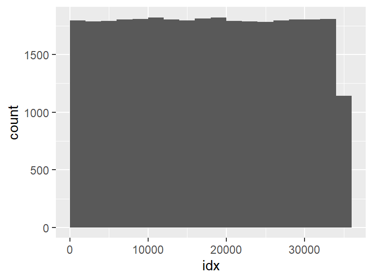

## brand

| Feature | Result |
| --- | --- |
| Variable type | character |
| Number of missing obs. | 0 (0 %) |
| Number of unique values | 4783 |
| Mode | “wal-mart stores, inc.” |

[figure not shown]

- The following suspected missing value codes enter as regular values: "…perfectly sweet".
- Note that the following levels have at most five observations: "“dirty”", "“fiesta”", "…perfectly sweet", "1000 & 1 bites", "15th ave food corp.", …, "zitner candy corp.", "zom bee", "zombie", "zumba goma", "zumba pica" (3923 values omitted).

## description

| Feature | Result |
| --- | --- |
| Variable type | character |
| Number of missing obs. | 0 (0 %) |
| Number of unique values | 26200 |
| Mode | “cookies” |

[figure not shown]

- Note that the following levels have at most five observations: "’nana pops nut butter filled supersnacks", "!holla nolla!, bon temps!, real restaurant tortilla chips", "“original” caramel creams", "“yep” chocolate bar", "(grass) hopper pie", …, "zucchini loaf", "zucchini nut crumb", "zumba goma mango", "zumba goma, candy, watermelon", "zumba pica chamoy bite candies" (25906 values omitted).